# Predicting Performance of Dumbell Curl from Accelerometer Data

Phillip Rowe

10/23/2019

## Executive Summary

We trained a random forest model and used it to make 20 predictions with 100% accuracy how a dumbell lift was being performed.

## Objective

The goal of this project is to create a model that predicts whether participants perform a dumbell curl correctly. Data was collected from four accelerometers, attached to the belt, forearm, arm, and dumbell of 6 participants who performed the lift in five different ways, labeled as follows: exactly according to the specification (Class A), throwing the elbows to the front (Class B), lifting the dumbbell only halfway (Class C), lowering the dumbbell only halfway (Class D) and throwing the hips to the front (Class E).

## Exploratory Data Analysis

In Figure 1, we plot the first two accelerometer variables (roll_belt and pitch_belt) and see they produce overlapping clusters depending on the class (type of lift). Each user, denoted by a different color, had a very different location of the cluster of readings. We denoted the correct lifts for each user in the upper left chart. The four incorrect lifts were shown in the upper right. The lower left plot is the correct lift of subject ‘pedro’ (shown in pink in the two upper charts), and the lower right is all five types of lift by ‘pedro.’ We are not sure why each user has a different mean for doing the same class of lift, but we assume the this could be explained by perhaps having differently calibrated accelerometers or their different body shapes or sizes. In any case, it is clear that the ‘big’ separation of each cluster and each subcluster would lend itself to a random forest or principal component analysis or support vector machine type of classification. Given the high performance of the random forest, we did not bother testing a SVM.

## How Model Was Built and Cross Validation

While we also tried a linear discriminant analysis (LDA) model with and without timestamps, the random forest model provided much better accuracy and was 100% accurate on the 20 test samples provided by Coursera. The caret package random forest function did not complete its calculation on a high powered laptop, for some reason, so we used the randomForest package instead.

Having over 14,000 observations in the original dataset (several thousand for each of the experimental subjects) seemed plenty of data, so the training data set was split into 75% training and 25% cross validation data.

Based on the confusion matrix in Figure 3, we see that the accuracy was 99.6%, meaning the error was less than 1%. We would expect our out of sample error to be similarly small, perhas slightly larger. We also calculated the error for a random forest that excluded user_name and found similar accuracy. Thus, the accelerometer reading alone were sufficient to generate an extremely accurate model.

We calculate the importance of each variable, showing that roll_belt was the most important. Figure 4 shows a summary of the random forest model with 500 trees.

```r
library("dplyr")
library(lubridate)
library(ggplot2)
#install.packages('downloader')
library(downloader)
library('stringr')
library('tibble')
library('reshape2')
library(ModelMetrics)
library(AppliedPredictiveModeling)
library(caret)
library(gbm)
library(MASS)

#---------------------------------------------------------------------------------------
#
# Load and Clean Data
#
#---------------------------------------------------------------------------------------
#
#url1<-'https://d396qusza40orc.cloudfront.net/predmachlearn/pml-training.csv'
#url2<-'https://d396qusza40orc.cloudfront.net/predmachlearn/pml-testing.csv'
#download(url1,dest="pml-training.csv")
#download(url2,dest='pml-testing.csv')
training<-read.csv('pml-training.csv')
testing<-read.csv('pml-testing.csv')

set.seed(123)
intrain<-createDataPartition(training$classe, p = .75)[[1]]
cvtrain<-training[-intrain,]
traintrain<-training[intrain,]
```

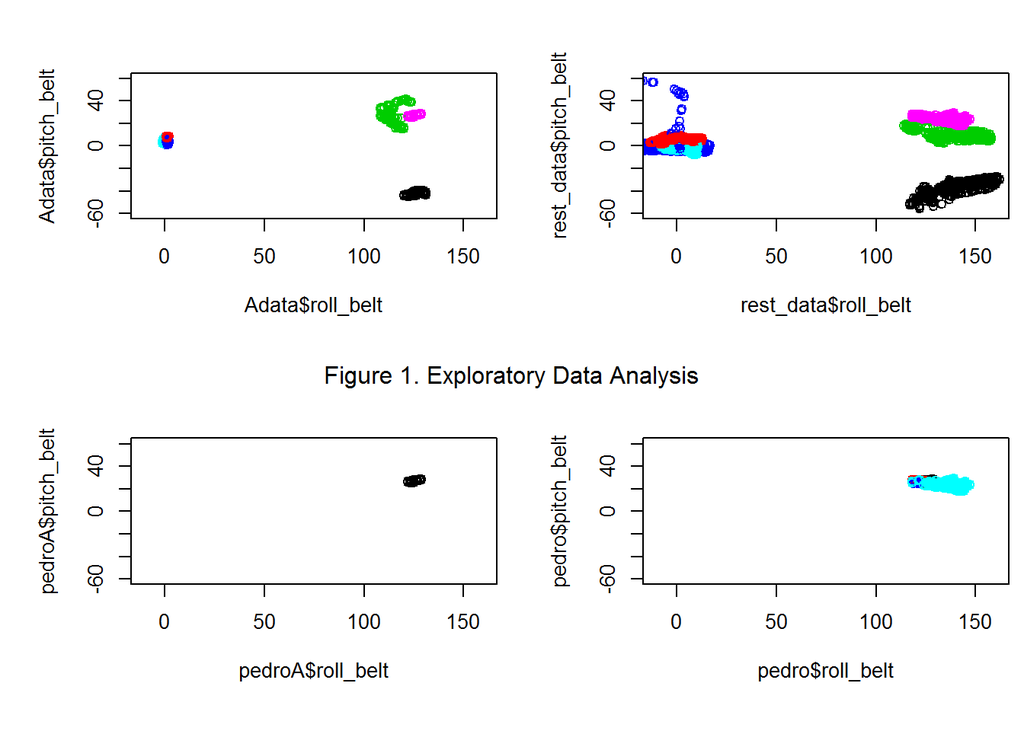

```r
# find which columns have lots of NAs, that way we can remove those columns

nas=c()
# a 160-long vector which shows how many NAs are in each column on traintrain dataframe
for (i in 1:160) {
    nas=c(nas,sum(is.na(traintrain[,i])))
}

nas_test=c()
# a 160-long vector which shows how many NAs are in each column on traintrain dataframe
for (i in 1:160) {
    nas_test=c(nas_test,sum(is.na(testing[,i])))
}
# we will train using gooddata, which only has full columns of data
gooddata=traintrain[,!(nas>1)]
goodcv = cvtrain[,!(nas>1)]
goodtest=testing[,!(nas_test>1)]

# removing the "X" or index column, since the data is stored sequentially, i.e., first all
# of class A, then all of class B, then all C, etc., so we shouldn't allow training to
# simply look at the index
gooddata=gooddata[,-1]
goodcv = goodcv[,-1]
goodtest=goodtest[,c(-1,-60)] # there is a 'problem_id' column in position 60

#plot(gooddata$roll_belt,gooddata$pitch_belt,col=gooddata$user_name, xlim=c(-10,160),
#     ylim=c(-60,60)))
#plot(gooddata$roll_belt,gooddata$pitch_belt,col=gooddata$classe, xlim=c(-10,160),
#     ylim=c(-60,60)))

#---------------------------------------------------------------------------------------
#
# Exploratory Data Analysis
#
#---------------------------------------------------------------------------------------

Adata=gooddata[gooddata$classe=='A',]
rest_data=gooddata[gooddata$classe!='A',]
carl=gooddata[gooddata$user_name=='carlitos',]
carlA=gooddata[(gooddata$classe=='A')&(gooddata$user_name=='carlitos'),]
pedro=gooddata[gooddata$user_name=='pedro',]
pedroA=gooddata[(gooddata$classe=='A')&(gooddata$user_name=='pedro'),]

par(mfrow=c(2,2), mai = c(1, 0.9, 0.5, .1))
plot(Adata$roll_belt,Adata$pitch_belt,col=Adata$user_name, xlim=c(-10,160), ylim=c(-60,60))
plot(rest_data$roll_belt,rest_data$pitch_belt,col=rest_data$user_name, xlim=c(-10,160),
     ylim=c(-60,60))

#plot(carl$roll_belt,carl$pitch_belt,col=carl$classe, xlim=c(-10,20), ylim=c(00,20))
#plot(carlA$roll_belt,carlA$pitch_belt,col=carlA$classe, xlim=c(-10,20), ylim=c(0,20))
#plot(pedroA$roll_belt,pedroA$pitch_belt,col=pedroA$classe, xlim=c(110,150), ylim=c(15,30))
#plot(pedro$roll_belt,pedro$pitch_belt,col=pedro$classe, xlim=c(110,150), ylim=c(15,30))
plot(pedroA$roll_belt,pedroA$pitch_belt,col=pedroA$classe, xlim=c(-10,160), ylim=c(-60,60))
plot(pedro$roll_belt,pedro$pitch_belt,col=pedro$classe, xlim=c(-10,160), ylim=c(-60,60))
mtext("Figure 1. Exploratory Data Analysis", side = 3, line = -16, outer = TRUE)
```

```r
# ---------------------------------------------------------------------------------------
# FIGURE 2.
#
# PCA decomposition shows how 12 components account for 81% of variance, so a discriminant
# analysis (i.e., lda) obviously makes sense as model choice.  LDA turns out to be less
# accurate than random forest, however.
# ---------------------------------------------------------------------------------------

# we exclude name label and timestamps and classe columns, leaving just accelerometer readings
model.pr <- prcomp(gooddata[,c(7:58)], center = TRUE, scale = TRUE)
summary(model.pr)
```

```
FALSE Importance of components:
FALSE                           PC1    PC2     PC3     PC4     PC5     PC6
FALSE Standard deviation     2.8941 2.8494 2.15043 2.07013 1.91676 1.73548
FALSE Proportion of Variance 0.1611 0.1561 0.08893 0.08241 0.07065 0.05792
FALSE Cumulative Proportion  0.1611 0.3172 0.40615 0.48856 0.55921 0.61713
FALSE                            PC7    PC8     PC9    PC10    PC11    PC12
FALSE Standard deviation     1.50112 1.4368 1.31037 1.22780 1.17456 1.05961
FALSE Proportion of Variance 0.04333 0.0397 0.03302 0.02899 0.02653 0.02159
FALSE Cumulative Proportion  0.66047 0.7002 0.73319 0.76218 0.78871 0.81030
FALSE                          PC13    PC14   PC15    PC16    PC17    PC18
FALSE Standard deviation     0.9939 0.94332 0.9035 0.88349 0.81871 0.75856
FALSE Proportion of Variance 0.0190 0.01711 0.0157 0.01501 0.01289 0.01107
FALSE Cumulative Proportion  0.8293 0.84641 0.8621 0.87712 0.89001 0.90107
FALSE                           PC19    PC20    PC21    PC22    PC23    PC24
FALSE Standard deviation     0.72051 0.69424 0.64820 0.62903 0.60673 0.57740
FALSE Proportion of Variance 0.00998 0.00927 0.00808 0.00761 0.00708 0.00641
FALSE Cumulative Proportion  0.91106 0.92033 0.92841 0.93602 0.94309 0.94951
FALSE                           PC25    PC26    PC27    PC28   PC29    PC30
FALSE Standard deviation     0.54706 0.53808 0.50447 0.48563 0.4501 0.42945
FALSE Proportion of Variance 0.00576 0.00557 0.00489 0.00454 0.0039 0.00355
FALSE Cumulative Proportion  0.95526 0.96083 0.96572 0.97026 0.9741 0.97770
FALSE                           PC31    PC32    PC33    PC34    PC35    PC36
FALSE Standard deviation     0.38868 0.36345 0.34512 0.33380 0.30289 0.28119
FALSE Proportion of Variance 0.00291 0.00254 0.00229 0.00214 0.00176 0.00152
FALSE Cumulative Proportion  0.98061 0.98315 0.98544 0.98758 0.98934 0.99086
FALSE                           PC37    PC38    PC39    PC40    PC41    PC42
FALSE Standard deviation     0.25293 0.23804 0.23516 0.19982 0.19237 0.18548
FALSE Proportion of Variance 0.00123 0.00109 0.00106 0.00077 0.00071 0.00066
FALSE Cumulative Proportion  0.99209 0.99318 0.99425 0.99502 0.99573 0.99639
FALSE                           PC43    PC44    PC45    PC46    PC47    PC48
FALSE Standard deviation     0.18047 0.17124 0.16655 0.16328 0.14550 0.14071
FALSE Proportion of Variance 0.00063 0.00056 0.00053 0.00051 0.00041 0.00038
FALSE Cumulative Proportion  0.99702 0.99758 0.99811 0.99863 0.99903 0.99941
FALSE                           PC49    PC50    PC51    PC52
FALSE Standard deviation     0.11373 0.09744 0.07728 0.04598
FALSE Proportion of Variance 0.00025 0.00018 0.00011 0.00004
FALSE Cumulative Proportion  0.99966 0.99984 0.99996 1.00000
```

```r
# ---------------------------------------------------------------------------------------
#
# Random Forest Model
#
# ---------------------------------------------------------------------------------------

set.seed(222)
library(randomForest)
# avoid including time stamps which would make it too easy
x_rf=gooddata[,c(-(2:6),-59)]
rf<-randomForest(x_rf,y=gooddata[,59])
# these others yield same accuracy
#rf2<-randomForest(gooddata[,-59],y=gooddata[,59])
#rf3<-randomForest(gooddata[,c(-1,-(2:6),-59)],y=gooddata[,59])

rf_cv=predict(rf,newdata=goodcv[,c(-(2:6),-59)])
#rf_cv3=predict(rf,newdata=goodcv[,c(-(2:6),-59)])

# ---------------------------------------------------------------------------------------
#
#  Figure 3. Confusion Matrix of Random Forest vs. Cross Validation Data
#
# ---------------------------------------------------------------------------------------
confusionMatrix(rf_cv,goodcv[,59])
```

```
FALSE Confusion Matrix and Statistics
FALSE
FALSE           Reference
FALSE Prediction    A    B    C    D    E
FALSE          A 1395    0    0    0    0
FALSE          B    0  949    9    0    0
FALSE          C    0    0  846    7    2
FALSE          D    0    0    0  797    2
FALSE          E    0    0    0    0  897
FALSE
FALSE Overall Statistics
FALSE
FALSE                Accuracy : 0.9959
FALSE                  95% CI : (0.9937, 0.9975)
FALSE     No Information Rate : 0.2845
FALSE     P-Value [Acc > NIR] : < 2.2e-16
FALSE
FALSE                   Kappa : 0.9948
FALSE
FALSE  Mcnemar's Test P-Value : NA
FALSE
FALSE Statistics by Class:
FALSE
FALSE                      Class: A Class: B Class: C Class: D Class: E
FALSE Sensitivity            1.0000   1.0000   0.9895   0.9913   0.9956
FALSE Specificity            1.0000   0.9977   0.9978   0.9995   1.0000
FALSE Pos Pred Value         1.0000   0.9906   0.9895   0.9975   1.0000
FALSE Neg Pred Value         1.0000   1.0000   0.9978   0.9983   0.9990
FALSE Prevalence             0.2845   0.1935   0.1743   0.1639   0.1837
FALSE Detection Rate         0.2845   0.1935   0.1725   0.1625   0.1829
FALSE Detection Prevalence   0.2845   0.1954   0.1743   0.1629   0.1829
FALSE Balanced Accuracy      1.0000   0.9989   0.9936   0.9954   0.9978
```

```r
#confusionMatrix(rf_cv3,goodcv[,59])

rf_pred=predict(rf,newdata=goodtest[,c(-(2:6))])
# agrees with pred_lda_test 18 out of 20 times; on index #2 and #8, both of which I got wrong # on quiz, so perhaps rf model is better?

rf_pred
```

```
FALSE  1  2  3  4  5  6  7  8  9 10 11 12 13 14 15 16 17 18 19 20
FALSE  B  A  B  A  A  E  D  B  A  A  B  C  B  A  E  E  A  B  B  B
FALSE Levels: A B C D E
```

```r
# 1  2  3  4  5  6  7  8  9 10 11 12 13 14 15 16 17 18 19 20
# B  A  B  A  A  E  D  B  A  A  B  C  B  A  E  E  A  B  B  B

# Shows error in relation to 3 trees; rf has 500 trees (near the max on the plot, I think,
# which minimizes the error rate)
plot(rf,type='l',amain=deparse(substitute(rf)), main='Figure 4. Error vs. # Trees')

var_rf=data.frame(cbind(names(x_rf),val=varImp(rf)[1:53,]))
var_rf$val=as.numeric(as.character(var_rf$val))
vars_rfsorted=var_rf[order(-var_rf[,2]),]

# ---------------------------------------------------------------------------------------
#
#  Variables Sorted by Importance
#
# ---------------------------------------------------------------------------------------
vars_rfsorted
```

```
FALSE                      V1       val
FALSE 2             roll_belt 916.90330
FALSE 4              yaw_belt 657.37028
FALSE 42        pitch_forearm 584.18729
FALSE 40    magnet_dumbbell_z 556.96623
FALSE 3            pitch_belt 521.05906
FALSE 39    magnet_dumbbell_y 507.87116
FALSE 41         roll_forearm 442.03984
FALSE 38    magnet_dumbbell_x 376.02351
FALSE 28        roll_dumbbell 319.23075
FALSE 36     accel_dumbbell_y 315.66368
FALSE 11         accel_belt_z 295.63481
FALSE 14        magnet_belt_z 288.41880
FALSE 13        magnet_belt_y 287.51347
FALSE 48      accel_forearm_x 248.70472
FALSE 8          gyros_belt_z 241.70486
FALSE 37     accel_dumbbell_z 240.38835
FALSE 15             roll_arm 226.75317
FALSE 53     magnet_forearm_z 206.34369
FALSE 31 total_accel_dumbbell 194.91273
FALSE 25         magnet_arm_x 194.67280
FALSE 30         yaw_dumbbell 187.96642
FALSE 17              yaw_arm 186.81851
FALSE 22          accel_arm_x 184.78789
FALSE 12        magnet_belt_x 184.34700
FALSE 35     accel_dumbbell_x 181.90633
FALSE 50      accel_forearm_z 178.99690
FALSE 33     gyros_dumbbell_y 177.52666
FALSE 5      total_accel_belt 169.75882
FALSE 51     magnet_forearm_x 166.23395
FALSE 52     magnet_forearm_y 165.77322
FALSE 26         magnet_arm_y 164.35295
FALSE 27         magnet_arm_z 144.29495
FALSE 16            pitch_arm 134.11140
FALSE 29       pitch_dumbbell 130.47359
FALSE 43          yaw_forearm 125.87995
FALSE 1             user_name 114.29017
FALSE 23          accel_arm_y 109.35011
FALSE 49      accel_forearm_y 106.43844
FALSE 20          gyros_arm_y 101.41775
FALSE 24          accel_arm_z  99.23328
FALSE 19          gyros_arm_x  96.24149
FALSE 46      gyros_forearm_y  95.94581
FALSE 32     gyros_dumbbell_x  92.56653
FALSE 10         accel_belt_y  89.73737
FALSE 9          accel_belt_x  87.81782
FALSE 44  total_accel_forearm  83.84904
FALSE 7          gyros_belt_y  83.32945
FALSE 18      total_accel_arm  73.65112
FALSE 6          gyros_belt_x  70.45782
FALSE 47      gyros_forearm_z  65.04304
FALSE 34     gyros_dumbbell_z  64.44977
FALSE 45      gyros_forearm_x  53.63074
FALSE 21          gyros_arm_z  42.45475
```

```r
rf
```

```
FALSE
FALSE Call:
FALSE  randomForest(x = x_rf, y = gooddata[, 59])
FALSE                Type of random forest: classification
FALSE                      Number of trees: 500
FALSE No. of variables tried at each split: 7
FALSE
FALSE         OOB estimate of  error rate: 0.52%
FALSE Confusion matrix:
FALSE      A    B    C    D    E class.error
FALSE A 4180    4    0    0    1 0.001194743
FALSE B    9 2833    6    0    0 0.005266854
FALSE C    0   10 2554    3    0 0.005064277
FALSE D    0    0   28 2381    3 0.012852405
FALSE E    0    0    3    9 2694 0.004434590
```

[figure not shown]